# Working with Messy Data

Christopher Teixeira  
November 15, 2023

The author’s affiliation with The MITRE Corporation is provided for identification pusposes only, and is not intended to convey or imply MITRE’s concurrence with, or support for, the positions, opinions or viewpoints expressed by the author.

## A little about me…

### Christopher Teixeira

### Principal Data Scientist

### The MITRE Corporation

#### Interests

- Data Analytics
- Applied Statistics
- Operations Research

#### Education

- MS in Operations Research, George Mason University
- BSc in Mathematics, Worcester Polytechnic Institute

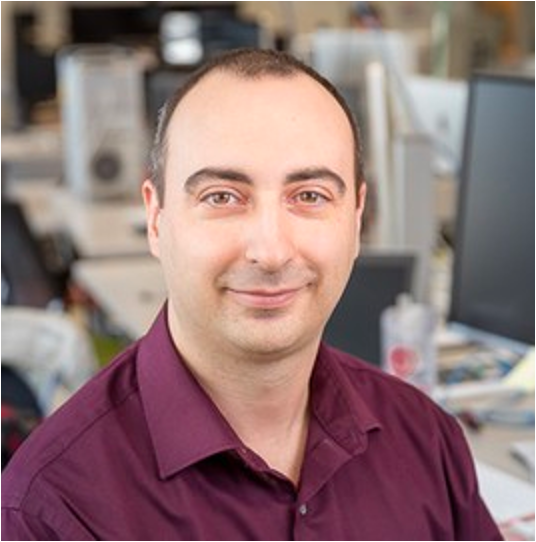

## Reading in data

- R
- Python

```r
# URL for the CMS data used in these slides
url <- "https://data.cms.gov/data-api/v1/dataset/8889d81e-2ee7-448f-8713-f071038289b5/data?size=5000"

# Download and convert the JSON file to a data frame
df <- jsonlite::fromJSON(url)

# View the data frame in a friendly format for Quarto
knitr::kable(head(df), format="html")
```

| Rndrng_NPI | Rndrng_Prvdr_Last_Org_Name | Rndrng_Prvdr_First_Name | Rndrng_Prvdr_MI | Rndrng_Prvdr_Crdntls | Rndrng_Prvdr_Gndr | Rndrng_Prvdr_Ent_Cd | Rndrng_Prvdr_St1 | Rndrng_Prvdr_St2 | Rndrng_Prvdr_City | Rndrng_Prvdr_State_Abrvtn | Rndrng_Prvdr_State_FIPS | Rndrng_Prvdr_Zip5 | Rndrng_Prvdr_RUCA | Rndrng_Prvdr_RUCA_Desc | Rndrng_Prvdr_Cntry | Rndrng_Prvdr_Type | Rndrng_Prvdr_Mdcr_Prtcptg_Ind | Tot_HCPCS_Cds | Tot_Benes | Tot_Srvcs | Tot_Sbmtd_Chrg | Tot_Mdcr_Alowd_Amt | Tot_Mdcr_Pymt_Amt | Tot_Mdcr_Stdzd_Amt | Drug_Sprsn_Ind | Drug_Tot_HCPCS_Cds | Drug_Tot_Benes | Drug_Tot_Srvcs | Drug_Sbmtd_Chrg | … |
| --- | --- | --- | --- | --- | --- | --- | --- | --- | --- | --- | --- | --- | --- | --- | --- | --- | --- | --- | --- | --- | --- | --- | --- | --- | --- | --- | --- | --- | --- | --- |
| 1003000126 | Enkeshafi | Ardalan |  | M.D. | M | I | 6410 Rockledge Dr Ste 304 |  | Bethesda | MD | 24 | 20817 | 1 | Metropolitan area core: primary flow within an urbanized area of 50,000 and greater | US | Internal Medicine | Y | 36 | 661 | 3749 | 515976.55 | 289822.37 | 231289.23 | 198266.66 | * |  |  |  |  | … |
| 1003000134 | Cibull | Thomas | L | M.D. | M | I | 2650 Ridge Ave | Evanston Hospital | Evanston | IL | 17 | 60201 | 1 | Metropolitan area core: primary flow within an urbanized area of 50,000 and greater | US | Pathology | Y | 21 | 3216 | 7359 | 1136431.94 | 273928.38 | 203094.28 | 191013.47 |  | 0 | 0 | 0 | 0 | … |
| 1003000142 | Khalil | Rashid |  | M.D. | M | I | 4126 N Holland Sylvania Rd | Suite 220 | Toledo | OH | 39 | 43623 | 1 | Metropolitan area core: primary flow within an urbanized area of 50,000 and greater | US | Anesthesiology | Y | 52 | 239 | 1932 | 295950.73 | 122731.08 | 93430.64 | 95509.35 |  | 5 | 32 | 898 | 8254.52 | … |
| 1003000423 | Velotta | Jennifer | A | M.D. | F | I | 11100 Euclid Ave |  | Cleveland | OH | 39 | 44106 | 1 | Metropolitan area core: primary flow within an urbanized area of 50,000 and greater | US | Obstetrics & Gynecology | Y | 19 | 69 | 738 | 21300 | 8017.57 | 6735.97 | 6892.83 | * |  |  |  |  | … |
| 1003000480 | Rothchild | Kevin | B | MD | M | I | 12605 E 16th Ave |  | Aurora | CO | 08 | 80045 | 1 | Metropolitan area core: primary flow within an urbanized area of 50,000 and greater | US | General Surgery | Y | 29 | 112 | 162 | 180891 | 35872.83 | 28071.92 | 27509.07 |  | 0 | 0 | 0 | 0 | … |
| 1003000530 | Semonche | Amanda | M | DO | F | I | 1021 Park Ave | Suite 203 | Quakertown | PA | 42 | 18951 | 1 | Metropolitan area core: primary flow within an urbanized area of 50,000 and greater | US | Internal Medicine | Y | 31 | 404 | 1487 | 257901 | 180753.38 | 140941.85 | 129609.8 |  | 5 | 106 | 120 | 14114 | … |

```python
import pandas as pd

# URL for the CMS data used in these slides
url = "https://data.cms.gov/data-api/v1/dataset/8889d81e-2ee7-448f-8713-f071038289b5/data?size=5000"

# Download and convert the JSON file to a data frame
df = pd.read_json(url)

# View the data frame in a friendly format for Quarto
df.to_html()
```

[output not shown]

## Changing data types

- R
- Python

```r
# Subset the data down to a select few to work with.
# Then convert "Bene_" and "Tot_" variables to numeric.
# The ID and zip code variables get converted to factors.
df.subset <- df |>
    select(Rndrng_NPI,
           Rndrng_Prvdr_Zip5,
           Tot_Benes,
           Tot_Srvcs,
           starts_with("Bene_")) |>
    mutate(across(starts_with(c("Bene_","Tot_")), as.numeric),
           across(starts_with("Rndrng_"), factor))

# View the data frame in a friendly format for Quarto
knitr::kable(head(df.subset), format="html")
```

| Rndrng_NPI | Rndrng_Prvdr_Zip5 | Tot_Benes | Tot_Srvcs | Bene_Avg_Age | Bene_Age_LT_65_Cnt | Bene_Age_65_74_Cnt | Bene_Age_75_84_Cnt | Bene_Age_GT_84_Cnt | Bene_Feml_Cnt | Bene_Male_Cnt | Bene_Race_Wht_Cnt | Bene_Race_Black_Cnt | Bene_Race_API_Cnt | Bene_Race_Hspnc_Cnt | Bene_Race_NatInd_Cnt | Bene_Race_Othr_Cnt | Bene_Dual_Cnt | Bene_Ndual_Cnt | Bene_CC_AF_Pct | Bene_CC_Alzhmr_Pct | Bene_CC_Asthma_Pct | Bene_CC_Cncr_Pct | Bene_CC_CHF_Pct | Bene_CC_CKD_Pct | Bene_CC_COPD_Pct | Bene_CC_Dprssn_Pct | Bene_CC_Dbts_Pct | Bene_CC_Hyplpdma_Pct | Bene_CC_Hyprtnsn_Pct | … |
| --- | --- | --- | --- | --- | --- | --- | --- | --- | --- | --- | --- | --- | --- | --- | --- | --- | --- | --- | --- | --- | --- | --- | --- | --- | --- | --- | --- | --- | --- | --- |
| 1003000126 | 20817 | 661 | 3749 | 78 | 42 | 197 | 247 | 175 | 378 | 283 | 469 | 83 | 62 | 14 | 0 | 33 | 188 | 473 | 0.24 | 0.30 | 0.12 | 0.16 | 0.39 | 0.52 | 0.24 | 0.37 | 0.44 | 0.75 | 0.75 | … |
| 1003000134 | 60201 | 3216 | 7359 | 76 | 88 | 1396 | 1198 | 534 | 1698 | 1518 | 2920 | 28 | 66 | 47 | 0 | 155 | 190 | 3026 | 0.10 | 0.07 | 0.05 | 0.14 | 0.11 | 0.24 | 0.06 | 0.15 | 0.20 | 0.52 | 0.51 | … |
| 1003000142 | 43623 | 239 | 1932 | 68 | 77 | 98 | 52 | 12 | 147 | 92 | 171 | 55 | NA | NA | 0 | NA | 74 | 165 | 0.09 | 0.06 | 0.09 | 0.11 | 0.21 | 0.37 | 0.21 | 0.39 | 0.38 | 0.58 | 0.70 | … |
| 1003000423 | 44106 | 69 | 738 | 66 | NA | 47 | NA | NA | 69 | 0 | NA | NA | NA | NA | NA | NA | 14 | 55 | NA | NA | NA | NA | NA | 0.16 | NA | 0.28 | 0.17 | 0.55 | 0.46 | … |
| 1003000480 | 80045 | 112 | 162 | 65 | 39 | 55 | NA | NA | 64 | 48 | 82 | NA | NA | 15 | 0 | NA | 46 | 66 | NA | NA | 0.18 | NA | 0.21 | 0.35 | 0.13 | 0.32 | 0.40 | 0.48 | 0.65 | … |
| 1003000530 | 18951 | 404 | 1487 | 72 | 50 | 206 | 110 | 38 | 237 | 167 | 383 | NA | NA | NA | NA | NA | 51 | 353 | 0.08 | 0.07 | 0.06 | 0.11 | 0.11 | 0.29 | 0.10 | 0.27 | 0.25 | 0.74 | 0.69 | … |

```python
# Subset down to the columns of interest.
cols = [0,12,19,20,41,42,43,44,45,46,47,48,49,50,51,52,53,54,55,56,57,58,59,60,61,62,63,64,65,66,67,68,69,70,71,72]
df_subset = df.iloc[:,cols]

# Convert character to numeric columns.
numeric_cols = df_subset.columns.drop(["Rndrng_NPI","Rndrng_Prvdr_Zip5"])
df_subset[numeric_cols]=df_subset[numeric_cols].apply(pd.to_numeric, errors='coerce')

# Convert ID and zip code columns to categorical.
categorical_cols = ["Rndrng_NPI","Rndrng_Prvdr_Zip5"]
df_subset[categorical_cols]=df_subset[categorical_cols].apply(pd.Categorical)
```

## Exploratory data analysis

Exploratory data analysis (EDA) is used by data scientists to analyze and investigate data sets and summarize their main characteristics, often employing data visualization methods. It helps determine how best to manipulate data sources to get the answers you need, making it easier for data scientists to discover patterns, spot anomalies, test a hypothesis, or check assumptions. <sup>1</sup>

Four primary types of EDA:

1. **Univariate non-graphical**: Describe the data and find patterns that exist within a variable.
2. **Univariate graphical**: For a single variable, explore the values visaully using graphs like box plots or histograms.
3. **Multivariate nongraphical**: Describe the relationships between two or more variables in the data.
4. **Multivariate graphical**: Visualize the relationships between two or more variables through graphs like scatter plots or heat maps,
[^1]: [IBM What is exploratory data analysis?](https://www.ibm.com/topics/exploratory-data-analysis)

## Applying EDA: Univariate

- R
- Python

```r
# Use the skimr package to examine the dataset.
# Produces a high level summary (# of rows/columns, column types)
# For each column type, it produces details about each variable.

library(skimr)
skim(df.subset)
```

Data summary

| Name | df.subset |
| --- | --- |
| Number of rows | 5000 |
| Number of columns | 36 |
| _______________________ |  |
| Column type frequency: |  |
| factor | 2 |
| numeric | 34 |
| ________________________ |  |
| Group variables | None |

**Variable type: factor**

| skim_variable | n_missing | complete_rate | ordered | n_unique | top_counts |
| --- | --- | --- | --- | --- | --- |
| Rndrng_NPI | 0 | 1 | FALSE | 5000 | 100: 1, 100: 1, 100: 1, 100: 1 |
| Rndrng_Prvdr_Zip5 | 0 | 1 | FALSE | 2809 | 770: 30, 559: 25, 021: 23, 100: 22 |

**Variable type: numeric**

| skim_variable | n_missing | complete_rate | mean | sd | p0 | p25 | p50 | p75 | p100 | hist |
| --- | --- | --- | --- | --- | --- | --- | --- | --- | --- | --- |
| Tot_Benes | 0 | 1.00 | 283.78 | 511.06 | 11.00 | 60.00 | 148.00 | 305.00 | 9843.00 | ▇▁▁▁▁ |
| Tot_Srvcs | 0 | 1.00 | 1718.13 | 10740.56 | 11.00 | 157.00 | 430.50 | 1151.25 | 462645.00 | ▇▁▁▁▁ |
| Bene_Avg_Age | 0 | 1.00 | 71.43 | 5.54 | 11.00 | 70.00 | 72.00 | 74.00 | 89.00 | ▁▁▁▇▅ |
| Bene_Age_LT_65_Cnt | 2011 | 0.60 | 53.89 | 74.11 | 0.00 | 21.00 | 35.00 | 58.00 | 1582.00 | ▇▁▁▁▁ |
| Bene_Age_65_74_Cnt | 792 | 0.84 | 142.20 | 237.40 | 0.00 | 40.00 | 79.00 | 145.00 | 4089.00 | ▇▁▁▁▁ |
| Bene_Age_75_84_Cnt | 1442 | 0.71 | 118.40 | 192.40 | 0.00 | 37.00 | 66.00 | 121.75 | 3734.00 | ▇▁▁▁▁ |
| Bene_Age_GT_84_Cnt | 2170 | 0.57 | 65.21 | 105.65 | 0.00 | 19.00 | 34.00 | 69.00 | 1708.00 | ▇▁▁▁▁ |
| Bene_Feml_Cnt | 613 | 0.88 | 180.66 | 307.23 | 0.00 | 49.00 | 101.00 | 192.00 | 5020.00 | ▇▁▁▁▁ |
| Bene_Male_Cnt | 613 | 0.88 | 138.98 | 237.98 | 0.00 | 35.00 | 75.00 | 147.50 | 4823.00 | ▇▁▁▁▁ |
| Bene_Race_Wht_Cnt | 1592 | 0.68 | 305.49 | 496.67 | 0.00 | 86.00 | 175.00 | 329.25 | 7942.00 | ▇▁▁▁▁ |
| Bene_Race_Black_Cnt | 3332 | 0.33 | 62.96 | 124.81 | 0.00 | 16.00 | 31.00 | 61.00 | 1781.00 | ▇▁▁▁▁ |
| Bene_Race_API_Cnt | 4094 | 0.18 | 23.43 | 52.69 | 0.00 | 0.00 | 11.00 | 26.00 | 741.00 | ▇▁▁▁▁ |
| Bene_Race_Hspnc_Cnt | 3665 | 0.27 | 48.70 | 88.57 | 0.00 | 13.00 | 24.00 | 47.00 | 928.00 | ▇▁▁▁▁ |
| Bene_Race_NatInd_Cnt | 3348 | 0.33 | 1.98 | 13.68 | 0.00 | 0.00 | 0.00 | 0.00 | 275.00 | ▇▁▁▁▁ |
| Bene_Race_Othr_Cnt | 4139 | 0.17 | 21.88 | 26.99 | 0.00 | 0.00 | 16.00 | 28.00 | 239.00 | ▇▁▁▁▁ |
| Bene_Dual_Cnt | 1321 | 0.74 | 80.12 | 137.01 | 0.00 | 22.00 | 42.00 | 84.00 | 2869.00 | ▇▁▁▁▁ |
| Bene_Ndual_Cnt | 1321 | 0.74 | 282.12 | 482.44 | 0.00 | 74.00 | 156.00 | 296.00 | 8396.00 | ▇▁▁▁▁ |
| Bene_CC_AF_Pct | 1577 | 0.68 | 0.17 | 0.10 | 0.00 | 0.10 | 0.15 | 0.23 | 0.75 | ▇▆▁▁▁ |
| Bene_CC_Alzhmr_Pct | 1623 | 0.68 | 0.21 | 0.16 | 0.00 | 0.09 | 0.16 | 0.29 | 0.75 | ▇▅▂▁▁ |
| Bene_CC_Asthma_Pct | 2008 | 0.60 | 0.10 | 0.05 | 0.00 | 0.07 | 0.09 | 0.12 | 0.46 | ▇▇▁▁▁ |
| Bene_CC_Cncr_Pct | 1623 | 0.68 | 0.15 | 0.11 | 0.00 | 0.10 | 0.13 | 0.17 | 0.75 | ▇▃▁▁▁ |
| Bene_CC_CHF_Pct | 1208 | 0.76 | 0.28 | 0.17 | 0.00 | 0.15 | 0.25 | 0.41 | 0.75 | ▇▇▅▃▁ |
| Bene_CC_CKD_Pct | 745 | 0.85 | 0.44 | 0.18 | 0.00 | 0.29 | 0.42 | 0.58 | 0.75 | ▁▇▇▇▆ |
| Bene_CC_COPD_Pct | 1452 | 0.71 | 0.20 | 0.11 | 0.00 | 0.12 | 0.19 | 0.27 | 0.75 | ▇▇▂▁▁ |
| Bene_CC_Dprssn_Pct | 751 | 0.85 | 0.33 | 0.15 | 0.00 | 0.23 | 0.31 | 0.40 | 0.75 | ▁▇▆▂▁ |
| Bene_CC_Dbts_Pct | 753 | 0.85 | 0.37 | 0.13 | 0.00 | 0.27 | 0.35 | 0.45 | 0.75 | ▁▆▇▅▁ |
| Bene_CC_Hyplpdma_Pct | 398 | 0.92 | 0.62 | 0.12 | 0.00 | 0.55 | 0.65 | 0.73 | 0.75 | ▁▁▁▃▇ |
| Bene_CC_Hyprtnsn_Pct | 299 | 0.94 | 0.68 | 0.11 | 0.00 | 0.63 | 0.74 | 0.75 | 0.75 | ▁▁▁▂▇ |
| Bene_CC_IHD_Pct | 774 | 0.85 | 0.42 | 0.16 | 0.00 | 0.29 | 0.40 | 0.53 | 0.75 | ▁▆▇▆▃ |
| Bene_CC_Opo_Pct | 1810 | 0.64 | 0.11 | 0.06 | 0.00 | 0.08 | 0.11 | 0.14 | 0.75 | ▇▂▁▁▁ |
| Bene_CC_RAOA_Pct | 528 | 0.89 | 0.49 | 0.13 | 0.00 | 0.40 | 0.48 | 0.56 | 0.75 | ▁▁▆▇▃ |
| Bene_CC_Sz_Pct | 2872 | 0.43 | 0.07 | 0.13 | 0.00 | 0.00 | 0.04 | 0.08 | 0.75 | ▇▁▁▁▁ |
| Bene_CC_Strok_Pct | 2339 | 0.53 | 0.11 | 0.10 | 0.00 | 0.04 | 0.09 | 0.15 | 0.75 | ▇▂▁▁▁ |
| Bene_Avg_Risk_Scre | 0 | 1.00 | 1.66 | 0.82 | 0.48 | 1.07 | 1.46 | 2.07 | 10.72 | ▇▁▁▁▁ |

## Applying EDA: Multivariate

- R
- Python

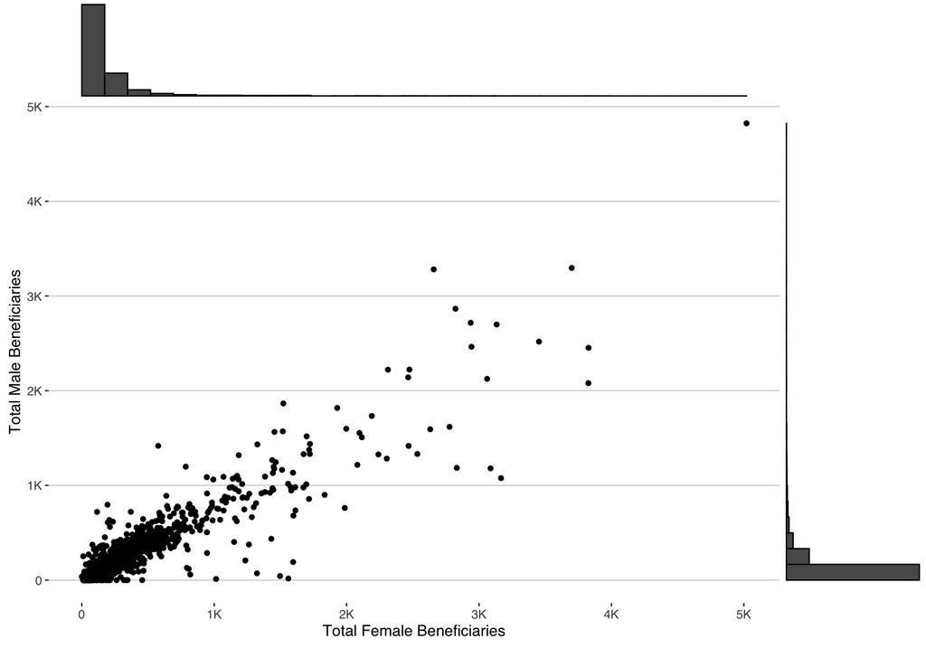

```r
library(ggplot2)
library(ggExtra)
library(ggthemes)

# Create a scatter plot with the number of beneficiaries by gender.
g <- ggplot(df.subset,
            aes(x=Bene_Feml_Cnt,
                y=Bene_Male_Cnt)) +
    geom_point() +
    theme(legend.position="none") +
    labs(x="Total Female Beneficiaries",
         y="Total Male Beneficiaries") +
    scale_x_continuous(labels=label_number(scale_cut=cut_short_scale())) +
    scale_y_continuous(labels=label_number(scale_cut=cut_short_scale())) +
    theme_hc()

ggMarginal(g, type="histogram")
```

# Working with missing data

## Questions to ask when working with missing data

- Does “missing” mean something different from “0”?
  - If you have data on the amount of candy sold per day, does a missing value mean no candy was sold? or the amount of candy sold is unknown?
- Is “missing” captured in another way?
  - Sometimes negative values or “99” can imply a value is missing.
- Was there a change in how data was being captured?
  - For long standing data capture initiatives (e.g., surveys), the data collection methods can change without notice to the analysts.
    - Was the way data was being capture changed?
    - Did the range of values change?
    - Do the values represent something different?
- Does it make sense to replace missing values?
  - If a variable is mostly missing, replacing it with any method could lead false conclusions.

## Imputing missing data

There are two general approaches:

- **Overly simple approach**: replace missing values with mean, median, or mode
- **Sophisticated approach**: replacing missing values by analyzing the full dataset and building a model per variable with missing data

## Multivariate Imputation by Chained Equations (MICE)

- R
- Python

```r
library(mice)

# Remove large dimensional variables
df.to.impute <- df.subset |> select(-Rndrng_NPI,-Rndrng_Prvdr_Zip5)

# Impute missing data using predictive mean matching
imputed <- df.to.impute |>
    mice(m=1, maxit=10, seed=42, method="pmm")

# Show the complete dataset including imputed values
complete(imputed)
```

[output not shown]

# Cautionary tales in working with data

## Data drift

Changes in the data can happen over time, resulting in “data drift” that can impact model performance or other decisions that can be overlooked if only near term changes are considered.

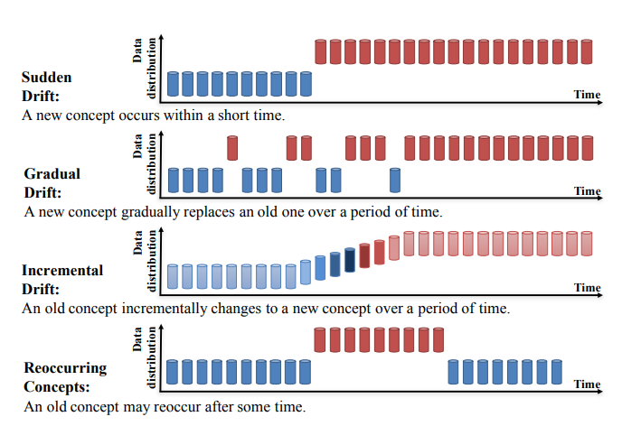

Image taken from [DataCamp](https://www.datacamp.com/tutorial/understanding-data-drift-model-drift).

## Cognitive biases

Cognitive biases are systematic patterns of deviation from norm and/or rationality in judgment. They are often studied in psychology, sociology and behavioral economics.<sup>1</sup>

Some biases to be aware of:

- **Survivorship bias**: Analyzing just the data that is available without analyzing the larger situation.
- **False causality**: Seeing correlation between two variables does not imply one causes the other to occur. <sup>2</sup>
- **Availability bias**: Drawing conclusions on limited data.
- **Confirmation bias**: Manipulating data to confirm your own hypothesis.
[^2]: Haselton MG, Nettle D, Andrews PW (2005). “The evolution of cognitive bias” (PDF). In Buss DM (ed.). The Handbook of Evolutionary Psychology. Hoboken, NJ: John Wiley & Sons Inc. pp. 724–746.
[^3]: Something fun to explore: [Spurious correlations](https://www.tylervigen.com/spurious-correlations)

## Simpson’s paradox

Simpson’s paradox occurs when groups of data show one particular trend, but this trend is reversed when the groups are combined together. Understanding and identifying this paradox is important for correctly interpreting data. <sup>1</sup>

A baseball player can have higher batting average than another on each of two years, but lower than the other when the two are combined. In one case, David Justice had a higher batting average than Derek Jeter in 1995 and 1996, but across the two years, Jeter’s average was higher. <sup>2</sup>

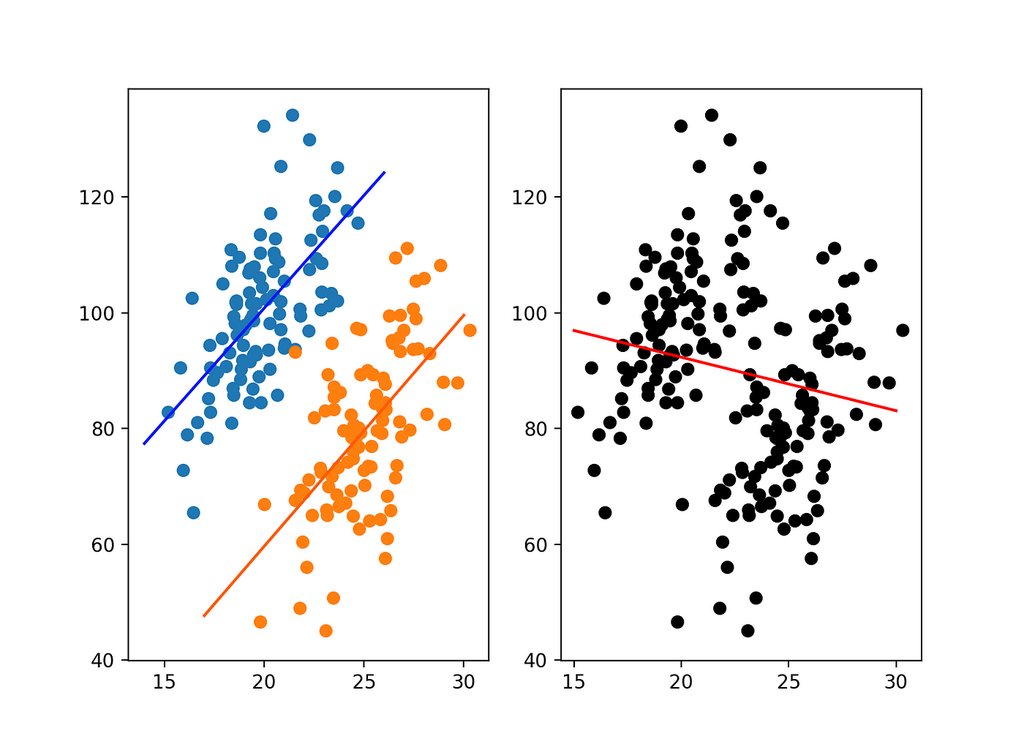

[^4]: Simpson, Edward H. (1951). “The Interpretation of Interaction in Contingency Tables”. Journal of the Royal Statistical Society, Series B. 13: 238–241.
[^5]: [Simpon’s Paradox by Brilliant](https://brilliant.org/wiki/simpsons-paradox)

## Goodhart’s law

*Any observed statistical regularity will tend to collapse once pressure is placed upon it for control purposes.* <sup>1</sup>

or a better way of putting it is:

**When a measure becomes a target, it ceases to be a good measure.** <sup>2</sup>

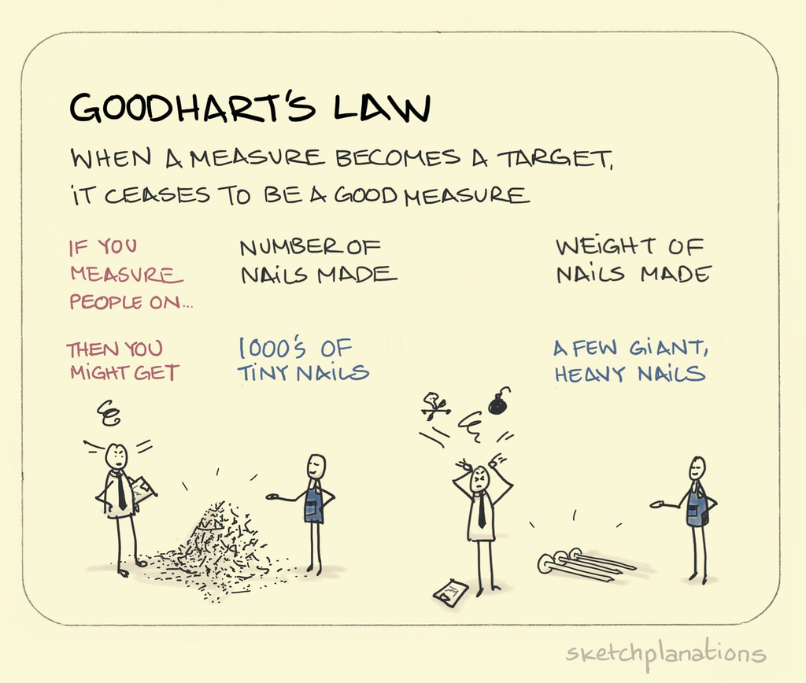

[^6]: Goodhart, Charles (1975). “Problems of Monetary Management: The U.K. Experience”. In Courakis, Anthony S. (ed.). Inflation, Depression, and Economic Policy in the West. Totowa, New Jersey: Barnes and Noble Books (published 1981). p. 116. ISBN 0-389-20144-8.
[^7]: Strathern, Marilyn (1997). “‘Improving ratings’: audit in the British University system”. European Review. John Wiley & Sons. 5 (3): 305–321.

# Sharing your data with others

## Reproducibility and Replicability

Reproducibility is the ability of independent investigators to draw the same conclusions from an experiment by following the documentation shared by the original investigators. Hence, reproducibility requires that another, independent team of investigators have to conduct the same experiment. <sup>1</sup>

Easy tips for enabling others to reproduce your work:

- Use a static random seed
  - in R: `set.seed(42)`
  - in Python: `random.seed(42)`
- Document your environment
  - in R: `library(renv)`
  - in Python: `pip freeze > requirements.txt`
- Use version control (e.g., Github, Bitbucket)
- Use notebooks
  - in R: [R Markdown](https://rmarkdown.rstudio.com/)
  - in Python: [Jupyter](https://jupyter.org/)
  - in either: [Quarto](https://quarto.org/)

[figure not shown]

<sup>2</sup>

[^8]: Gundersen Odd Erik. 2021. The fundamental principles of reproducibility. *Phil. Trans. R. Soc. A.* 379: 20200210. http://doi.org/10.1098/rsta.2020.0210
[^9]: [xkcd 242](https://xkcd.com/242/)

## Using pins

The pins package publishes data, models, and other R objects, making it easy to share them across projects and with your colleagues. You can pin objects to a variety of pin boards, including:

- folders (to share on a networked drive or with services like DropBox)
- Posit Connect
- Amazon S3
- Google Cloud Storage
- Azure storage
- Microsoft 365 (OneDrive and SharePoint).

Pins can be automatically versioned, making it straightforward to track changes, re-run analyses on historical data, and undo mistakes.<sup>1</sup> Pins is available in [R](https://pins.rstudio.com/) and [Python](https://rstudio.github.io/pins-python/).

[^10]: https://pins.rstudio.com/

## Discussion / Contact Info

### Christopher Teixeira

christopherteixeira.com

chris@christopherteixeira.com

[in/christopherteixeira](https://www.linkedin.com/in/christopherteixeira/)

christopher-teixeira

[figure not shown]

[figure not shown]

© 2023 THE MITRE CORPORATION. ALL RIGHTS RESERVED. Approved for public release; distribution unlimited. Case number 23-03859-1.

[xkcd 2494](https://xkcd.com/2494/)